# Pràctica 1

Marina Garcia Baco i Malena Ortolà Bilbao

2025-03-03

# Anàlisi de les relacions seqüència-estructura-funció de la proteïna glicosiltransferasa a Nicotiana tabacum (PDB: 8CHD)

- Estructura secundària
- Estructura supersecundària
- Plegament
- Funció

El codi [PDB:8CHD](https://www.rcsb.org/structure/8CHD) correspon a l’estructura de la proteïna glicosiltransferasa,codi [UNIPROT:A0A1S4A9U5](https://www.uniprot.org/uniprot/A0A1S4A9U5), amb una gran conservació de seqüència pel que es pot veure a l’[alineament](https://www.rcsb.org/uniprot/A0A1S4A9U5) que el propi PDB ens dona.

```
>8CHD
MEATQRDGGAQSPTPHVVMLPSPGMGHLIPLLEFAKRLLFLHRFTVTFAIPSGDPPSKAQ…
```

## Estructura secundària

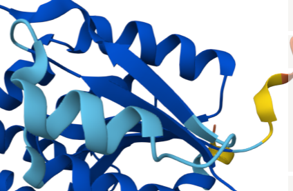

Imatge de la proteïna mostrant els elements d’estructura secundària.

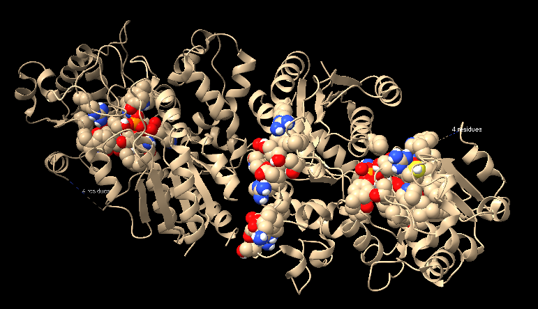

## Estructura supersecundària

Malauradament el fitxer PBD no conté massa informació sobre l’estructura secundària i no en podem treure massa profit, en aquest cas.

## Plegament

La glicosiltransferasa amb codi PDB: 8CHD presenta un plegament característic de la superfamília de les nucleotidil-difosfat-sugar transferases. Aquest tipus de plegament es caracteritza per un nucli central format per una làmina β de set filaments, flanquejada per hèlixs α en ambdós costats, formant una estructura $\alpha/\beta$. Aquestes característiques són comunes en enzims que catalitzen la transferència de grups glicosil de nucleòtids-sugar activats a acceptors específics, com sucres, lípids o proteïnes.

## Funció

Podem començar per [cercar a PFAM el codi uniprot de la proteïna](https://www.ebi.ac.uk/interpro/protein/UniProt/A0A1S4A9U5/entry/pfam/#table). Veiem que es tracta d’una proteïna amb un sol domini ben caracteritzat:

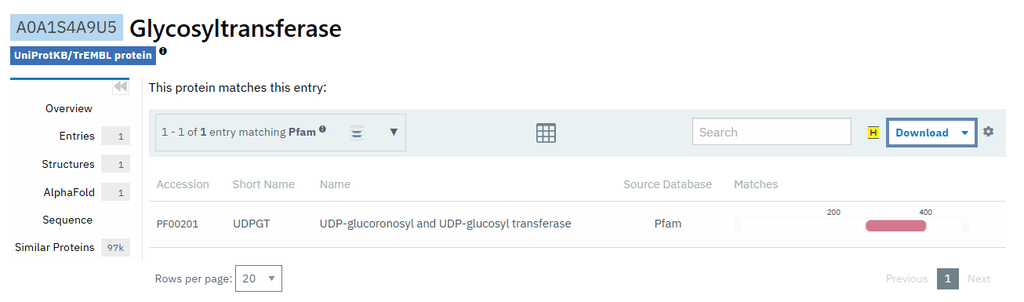

Taula resum dels dominis PFAM per al PDB:8CHD, UNIPROT: A0A1S4A9U5

Podem aleshores explorar l’entrada per a aquest domini específic: PFAM: PF00201, i observem que es tracta d’una UGT. El domini està altament distribuït, trobat en més de [1065 arquitectures de domini](https://www.ebi.ac.uk/interpro/entry/pfam/PF00201/domain_architecture/)

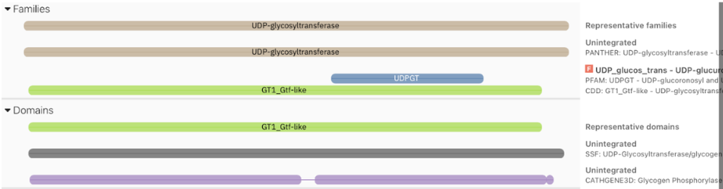

Taula resum dels dominis PFAM per al PDB:8CHD, UNIPROT: A0A1S4A9U5

Un cop explorem aquest domini, ens adonem que es tracta d’una UDP-glycosyl transferase.

Aquesta familia d’enzims catalitza la transferència d’una molècula de glucosa (o altre sucres) des de uridine diphosphate-sugars (UDP-sucres) fins a molècules acceptores, generalment un compost hidroxilat, com un fenol, alcohol, amina o àcid carboxílic.

Aquest procés es coneix com a glucosilació o glicosiltransferència. Influència processos metabòlics clau, com la modificació de proteïnes i la biosíntesi de metabòlits secundaris.

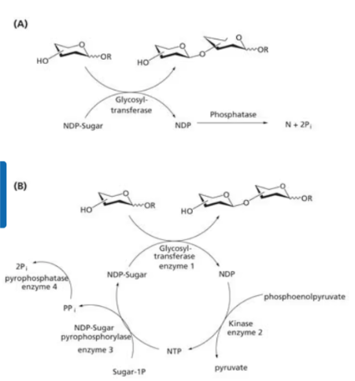

Imatge d’un exemple de reacció catalitzada per l’enzim PDB:8CHD, UNIPROT: A0A1S4A9U5

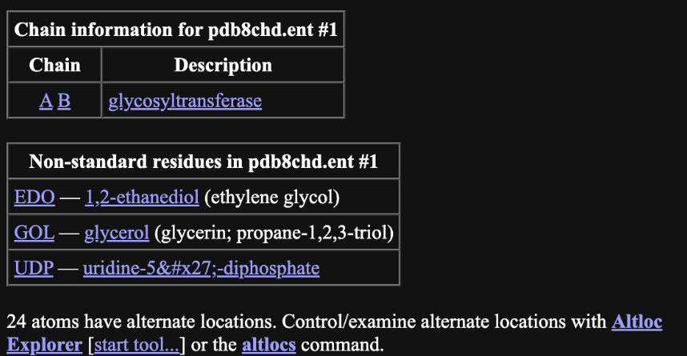